# PST.RGT.hybrids

Sarah Mueller

2025-06-16

## Load genome information.

```r
category <- read.delim("/dss/dsslegfs01/pr53da/pr53da-dss-0034/projects/2021_SwallowRRBS/0_Pre-processing/4_methyl_calling/1_CpG_islands/168.20miss/homer.cpgi.prop.168.merged.20miss.rmlowv.rmout.txt", header=T)

#separate chr and pos columns
category <- category %>%
  separate(loci.id, into = c("chr", "pos"), sep = "_", remove = FALSE) %>%
  distinct(chr, pos, .keep_all = TRUE) %>%
  mutate(pos = as.numeric(pos))

#get rid of leading and trailing white spaces
category$category <- trimws(category$category)

#specify region
category <- category %>%
  mutate(region = sub("_.*", "", category))
```

## Load methylation and PST information and look for only the highest Pst sites

```r
pst_site <- read.table("/dss/dsslegfs01/pr53da/pr53da-dss-0034/projects/2021_SwallowRRBS/2_Divergence/1_PST/0_cpgi_pst/0_pst_cpgi_c05.txt", header=T)

pst_RGT <- pst_site %>% select(site.id, gutturalis.vs.rustica.r.pst, gutturalis.vs.tytleri.pst, rustica.r.vs.tytleri.pst)

# Reshape the PST data into long form
pst_RGT_long <- pst_RGT %>%
  pivot_longer(-site.id, names_to = "comparison", values_to = "pst") %>%
  drop_na() %>%
  separate(comparison, into = c("pop1", "pop2"), sep = "\\.vs\\.") %>%
  mutate(pop2 = gsub("\\.pst$", "", pop2))

top_1_pct_pst <- pst_RGT_long %>%
  group_by(pop1,pop2) %>%
  arrange(desc(pst)) %>%
  mutate(rank = row_number()) %>%
  group_by(pop1,pop2) %>%
  filter(pst >= quantile(pst, 0.99, na.rm = TRUE)) %>%
  ungroup() %>%
  select(-rank) # Remove rank column if not needed
```

#Look to see if top 1% PST differs between RG and RT parentals

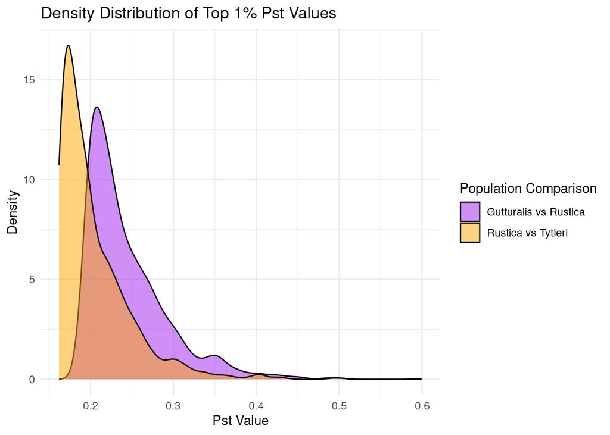

```r
# Plot the distribution of the top1% of PST between RG and RT comparisons
# Filter the data for the two specific comparisons
# and create a grouping variable for the colors
plot_data <- top_1_pct_pst %>%
  filter(
    (pop1 == "gutturalis" & pop2 == "rustica.r") |
    (pop1 == "rustica.r" & pop2 == "tytleri")
  ) %>%
  mutate(comparison = case_when(
    pop1 == "gutturalis" & pop2 == "rustica.r" ~ "Gutturalis vs Rustica",
    pop1 == "rustica.r" & pop2 == "tytleri" ~ "Rustica vs Tytleri"
  ))

# 2. Create the histogram
ggplot(plot_data, aes(x = pst, fill = comparison)) +
  geom_density(alpha = 0.5) + # alpha adds transparency so overlaps are visible
  scale_fill_manual(values = c(
    "Gutturalis vs Rustica" = "purple",
    "Rustica vs Tytleri" = "orange"
  )) +
  theme_minimal() +
  labs(
    title = "Density Distribution of Top 1% Pst Values",
    x = "Pst Value",
    y = "Density",
    fill = "Population Comparison"
  )
```

```r
# Extract the Pst values for each group
gutt_rustica <- top_1_pct_pst %>%
  filter(pop1 == "gutturalis", pop2 == "rustica.r") %>%
  pull(pst)

summary(gutt_rustica)
```

```
##    Min. 1st Qu.  Median    Mean 3rd Qu.    Max.
##  0.1940  0.2082  0.2285  0.2444  0.2666  0.5994
```

```r
rust_tytleri <- top_1_pct_pst %>%
  filter(pop1 == "rustica.r", pop2 == "tytleri") %>%
  pull(pst)

summary(rust_tytleri)
```

```
##    Min. 1st Qu.  Median    Mean 3rd Qu.    Max.
##  0.1621  0.1737  0.1910  0.2046  0.2219  0.4997
```

```r
#Check for normality
shapiro.test(gutt_rustica)
```

```
##
##  Shapiro-Wilk normality test
##
## data:  gutt_rustica
## W = 0.83194, p-value < 2.2e-16
```

```r
shapiro.test(rust_tytleri)
```

```
##
##  Shapiro-Wilk normality test
##
## data:  rust_tytleri
## W = 0.79797, p-value < 2.2e-16
```

```r
#Use non-parametric
wilcox_test_result <- wilcox.test(gutt_rustica, rust_tytleri)
print(wilcox_test_result)
```

```
##
##  Wilcoxon rank sum test with continuity correction
##
## data:  gutt_rustica and rust_tytleri
## W = 1242990, p-value < 2.2e-16
## alternative hypothesis: true location shift is not equal to 0
```

## Differences in methylation in parental populations

In this case I am still looking at the top 1% of outlier PST loci between the 3 parental populations, the same threshold that was used for the PST/FST testing. We do not have hybrids from the G-T hybrid zone, but I thought it is still interesting to look at parental population comparisons. Generally intergenic and intron regions are represented in these outlier PST loci.

```r
top_1_pct_pst <- top_1_pct_pst %>%
  separate(site.id, into = c("chr", "pos"), remove=FALSE) %>%
  mutate(pos = as.numeric(pos))
```

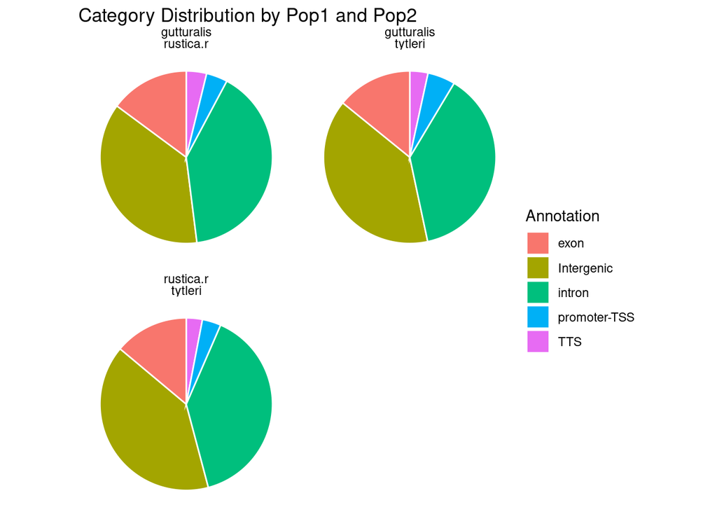

```r
top_1_pst_rgt_cat <- top_1_pct_pst %>%
  left_join(category, by = c("site.id" = "region.id"))

top_1_pst_rgt_cat %>%
  group_by(pop1, pop2, Annotation) %>%
  summarise(count = n()) %>%
  ungroup() %>%
  ggplot(aes(x = "", y = count, fill = Annotation)) +
  geom_bar(stat = "identity", width = 1, color = "white") +
  coord_polar(theta = "y") + # Convert the bar chart into a pie chart
  facet_wrap(~ pop1 + pop2, scales = "free", ncol = 2) +  # Facet by pop1 and pop2 combinations
  theme_void() +  # Removes axes and gridlines
  theme(legend.position = "right") +
  labs(title = "Category Distribution by Pop1 and Pop2") # Add a title
```

```r
# Step 1: Create a contingency table of counts by pop1, pop2, and category
category_counts <- top_1_pst_rgt_cat %>%
  group_by(pop1, pop2, category) %>%
  summarise(count = n(), .groups = "drop") %>%
  spread(key = category, value = count, fill = 0)  # Converts categories into separate columns for easy analysis


# Step 1: Create a contingency table of counts by pop1, pop2, and category
region_counts <- top_1_pst_rgt_cat %>%
  group_by(pop1, pop2, region) %>%
  summarise(count = n(), .groups = "drop") %>%
  spread(key = region, value = count, fill = 0)  # Converts categories into separate columns for easy analysis

# Step 2: Perform Chi-Square Test and view contingency table
chi_square_results <- region_counts %>%
  group_by(pop1, pop2) %>%
  do({
    # Subset the data for the current pop1-pop2 group
    contingency_table <- .[ , c("opensea", setdiff(names(.), c("pop1", "pop2", "opensea")))]

    # Perform the chi-square test
    chi_test <- chisq.test(contingency_table)

    # Store the results
    tibble(pop1 = unique(.$pop1),
           pop2 = unique(.$pop2),
           chi_squared = chi_test$statistic,
           p_value = chi_test$p.value)
  }) %>%
  ungroup()
```

## Overlapping high PST windows between parental pairs of populations

Do outlier PST loci tend to overlap? If yes, it could be a sign of selection on specific advantegous sites. If not, it may indicate drift. Here there are no sites which overlap between all three parental population commparisons. However, the lack of this could also indicate that there are different selective pressures.

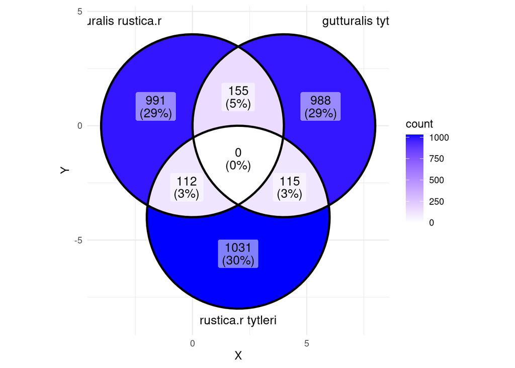

```r
# Identify unique genomic regions (chr + window_end) per list_id
overlap_sets <- top_1_pst_rgt_cat %>%
  group_by(pop1, pop2) %>%
  summarise(regions = list(site.id)) %>%
  pull(regions) %>%
  setNames(paste(top_1_pst_rgt_cat$pop1, top_1_pst_rgt_cat$pop2) %>% unique())

# Plot Venn diagram
ggVennDiagram(overlap_sets) +
  scale_fill_gradient(low = "white", high = "blue") +
  theme_minimal()
```

```r
##CHeck these overlapping sites
overlap_df <- tibble(
  site.id = unique(unlist(overlap_sets))
) %>%
  mutate(
    in_pop1_pop2 = site.id %in% overlap_sets[[1]],
    in_pop1_pop3 = site.id %in% overlap_sets[[2]],
    in_pop2_pop3 = site.id %in% overlap_sets[[3]],
    n_comparisons = in_pop1_pop2 + in_pop1_pop3 + in_pop2_pop3
  )

filter(overlap_df, n_comparisons == 3)  # shared by all
```

```
## # A tibble: 0 × 5
## # ℹ 5 variables: site.id <chr>, in_pop1_pop2 <lgl>, in_pop1_pop3 <lgl>,
## #   in_pop2_pop3 <lgl>, n_comparisons <int>
```

```r
overlap_2 <- filter(overlap_df, n_comparisons == 2)  # shared by exactly two
filter(overlap_df, n_comparisons == 1)  # unique
```

```
## # A tibble: 3,010 × 5
##    site.id                 in_pop1_pop2 in_pop1_pop3 in_pop2_pop3 n_comparisons
##    <chr>                   <lgl>        <lgl>        <lgl>                <int>
##  1 chr12_20582389          TRUE         FALSE        FALSE                    1
##  2 chr15_13241970_13243970 TRUE         FALSE        FALSE                    1
##  3 chr12_20095509          TRUE         FALSE        FALSE                    1
##  4 chr03_10590960          TRUE         FALSE        FALSE                    1
##  5 chr08_20411736_20412096 TRUE         FALSE        FALSE                    1
##  6 chr01_48691529          TRUE         FALSE        FALSE                    1
##  7 chr08_593936_594306     TRUE         FALSE        FALSE                    1
##  8 chr15_4773444_4773749   TRUE         FALSE        FALSE                    1
##  9 chr01_73684955          TRUE         FALSE        FALSE                    1
## 10 chr01A_40799028         TRUE         FALSE        FALSE                    1
## # ℹ 3,000 more rows
```

```r
overlap_2 <- left_join(overlap_2, top_1_pct_pst, by = "site.id")
```

High PST islands/shores and sites are mainly unique to each population comparison, which is not the case for FST windows.

## Heatmaps between populations of highest PST loci

First, I plot all three parental populations together, just to get an overview. After, I plot only RG comparisons in the top 1% of PST loci.

```r
prop.RGT <- read.delim("/dss/dsslegfs01/pr53da/pr53da-dss-0034/projects/2021_SwallowRRBS/0_Pre-processing/4_methyl_calling/1_CpG_islands/168.20miss/homer.cpgi.prop.168.merged.20miss.rmlowv.rmout.txt", header=T)

prop.df <- prop.RGT %>%
  dplyr::select(contains("RU_13_R_") | contains("_G_") | contains("_T_") | contains("region.id"))

top_1_pst_rgt_site <- top_1_pst_rgt_cat %>%
  dplyr::select("site.id")

pst_prop <- top_1_pst_rgt_site %>%
  left_join(prop.df, by = c("site.id" = "region.id"))

numeric_data <- pst_prop %>%
  select(-site.id)

# Convert the dataframe to a matrix
numeric_matrix <- as.matrix(numeric_data)

#Optional: set row names as site.id for better readability on the heatmap
#rownames(numeric_matrix) <- pst_prop$site.id

## Plotting for heatmap
ha <- HeatmapAnnotation(summary = anno_summary(gp = gpar(fill = 2),
                                               height = unit(2, "cm")))
h1 <- Heatmap(numeric_matrix, cluster_rows = T,
            column_labels = colnames(numeric_matrix), name="Methylation at PST outliers",
            cluster_columns = F)
```

[output not shown]

[output not shown]

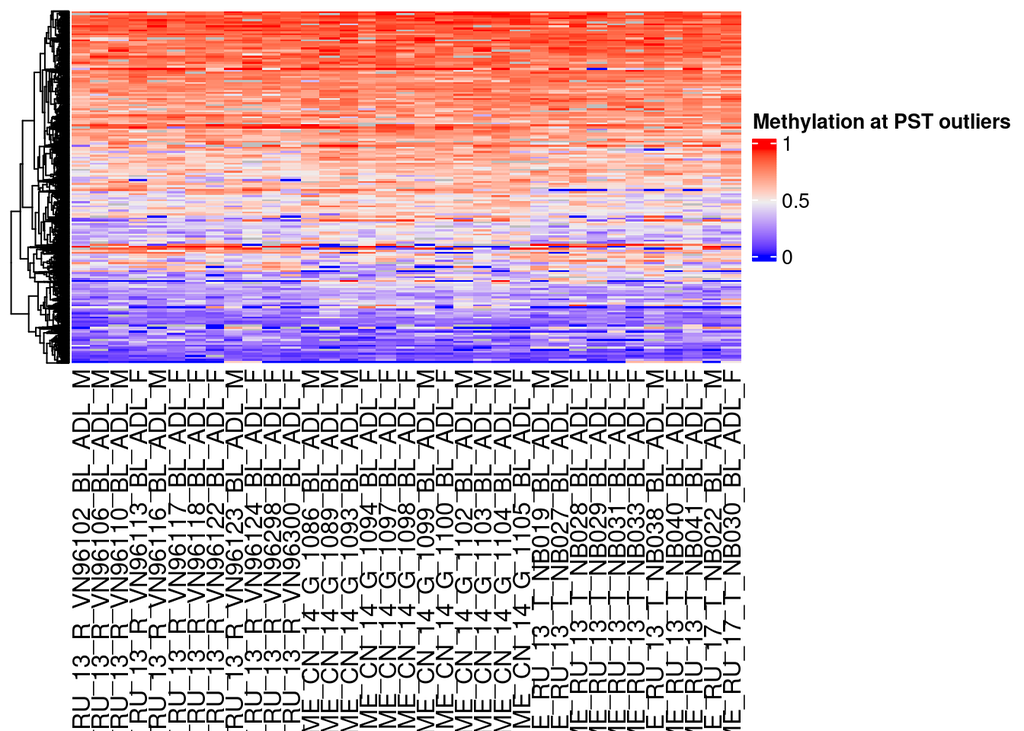

```r
h1
```

## rustica-gutturalis tests

I want to now plot only rustica-gutturalis PST outliers and look at methylation values at these loci, and if they differ acroos the mean of each population. (Scripts to run significance tests are separate). This is to create a visual heatmap of all PST outliers and the methylation values in rustica and gutturalis separately.

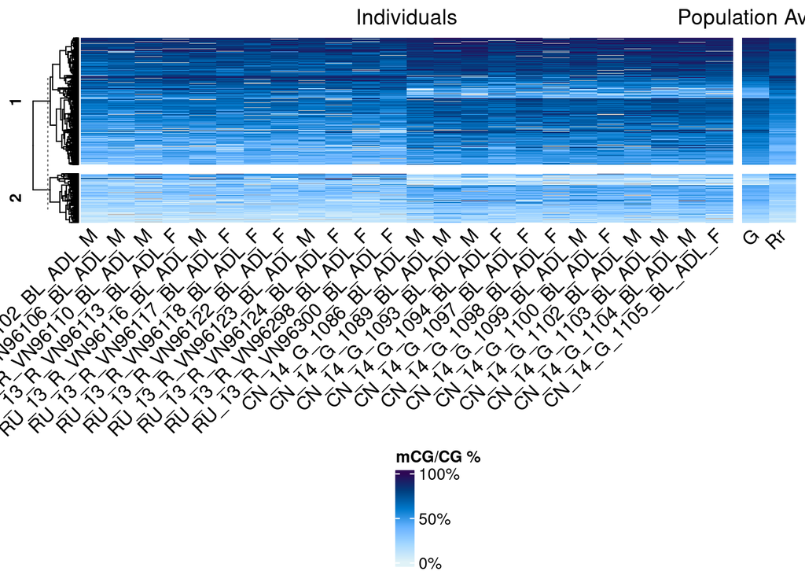

```r
# --- Data Preparation ---
pst_rg <- top_1_pst_rgt_cat %>%
  filter(pop1 == "gutturalis", pop2 == "rustica.r")

prop.df <- prop.RGT %>%
  dplyr::select(contains("RU_13_R_") | contains("_G_") | contains("region"))

population_groups <- list(Rr = "RU_13_R_", G = "_G_")

population_means <- sapply(names(population_groups), function(pop) {
  cols <- grep(population_groups[[pop]], colnames(prop.df), value = TRUE)
  if (length(cols) == 0) return(NULL)
  apply(prop.df[, cols, drop = FALSE], 1, function(x) mean(x, na.rm = TRUE))
})

prop.rg <- cbind(prop.df, population_means) %>%
  dplyr::select(region.id, Rr, G)

pst_prop <- pst_rg %>%
  left_join(prop.rg, by = c("site.id" = "region.id"))

# This is now the primary data for the heatmap
numeric_matrix <- pst_prop %>%
  dplyr::select(matches("RU.*_R_"), matches("CN.*_G_"), G, Rr) %>%
  dplyr::rename_with(~ str_remove(., "ME_")) %>%
  as.matrix()

# Set row names for the matrix
rownames(numeric_matrix) <- pst_prop$site.id

# --- Ordering and Splitting for Heatmap ---

# Perform hierarchical clustering on rows (methylation loci)
set.seed(123) # For reproducibility
row_hclust <- hclust(dist(numeric_matrix))
row_order <- row_hclust$order

# Reorder the numeric_matrix based on clustering
numeric_matrix <- numeric_matrix[row_order, ]

# Define row splits based on clustering
num_splits <- 2 # Adjust as needed for the desired number of blocks
cluster_assignments_ordered <- cutree(row_hclust, k = num_splits)[row_order]
final_row_split <- as.character(cluster_assignments_ordered)

# Define column splits
last_two_columns <- c(rep("Individuals", ncol(numeric_matrix) - 2), rep("Population Average", 2))

# Define heatmap colors
heatmap_colors <- colorRampPalette(c("#E0F2F7", "#A5D8FF", "#66B2FF", "#007ACC", "#004080", "#2E0854"))(100)

# --- Create Heatmap ---
rg1 <- Heatmap(numeric_matrix,
               cluster_rows = TRUE,
               show_row_dend = TRUE,
               col = heatmap_colors,
               name = "mCG/CG %",
               cluster_columns = FALSE,
               row_split = final_row_split,
               column_split = last_two_columns,
               show_row_names = FALSE,
               show_column_names = TRUE,
               column_names_rot = 45,
               row_title_rot = 90,
               row_title_gp = gpar(fontsize = 10, fontface = "bold"),
               row_gap = unit(2, "mm"),
               column_gap = unit(2, "mm"),
               heatmap_legend_param = list(
                 title = "mCG/CG %",
                 at = c(0, 0.5, 1),
                 labels = c("0%", "50%", "100%")
               )
)

# Draw the heatmap
draw(rg1, heatmap_legend_side = "bottom")
```

## Plot using only population means

Visually it is still too much information using all the individuals, so I will now only use population means for each CpG island/flank/site.

```r
# --- Data Preparation ---
pst_rg <- top_1_pst_rgt_cat %>%
  filter(pop1 == "gutturalis", pop2 == "rustica.r")

prop.df <- prop.RGT %>%
  dplyr::select(contains("RU_13_R_") | contains("_G_") | contains("region.id"))

population_groups <- list(Rr = "RU_13_R_", G = "_G_")

population_means <- sapply(names(population_groups), function(pop) {
  cols <- grep(population_groups[[pop]], colnames(prop.df), value = TRUE)
  if (length(cols) == 0) return(NULL)
  apply(prop.df[, cols, drop = FALSE], 1, function(x) mean(x, na.rm = TRUE))
})

prop.rg <- cbind(prop.df, population_means) %>%
  dplyr::select(region.id, Rr, G)

pst_prop <- pst_rg %>%
  left_join(prop.rg, by = c("site.id" = "region.id"))

pst_prop_islands <- pst_prop %>%
  filter(!region == "opensea")

pst_prop_open <- pst_prop %>%
  filter(region == "opensea")

# Filter numeric_matrix to only include population averages (G and Rr)
numeric_matrix_original <- pst_prop_islands %>%
  dplyr::select(G, Rr) %>% # Original order
  as.matrix()

# Reorder columns for horizontal flip if desired (Rr then G)
numeric_matrix_original <- numeric_matrix_original[, c("Rr", "G")]

# Set row names for the original matrix
rownames(numeric_matrix_original) <- pst_prop$region.id
```

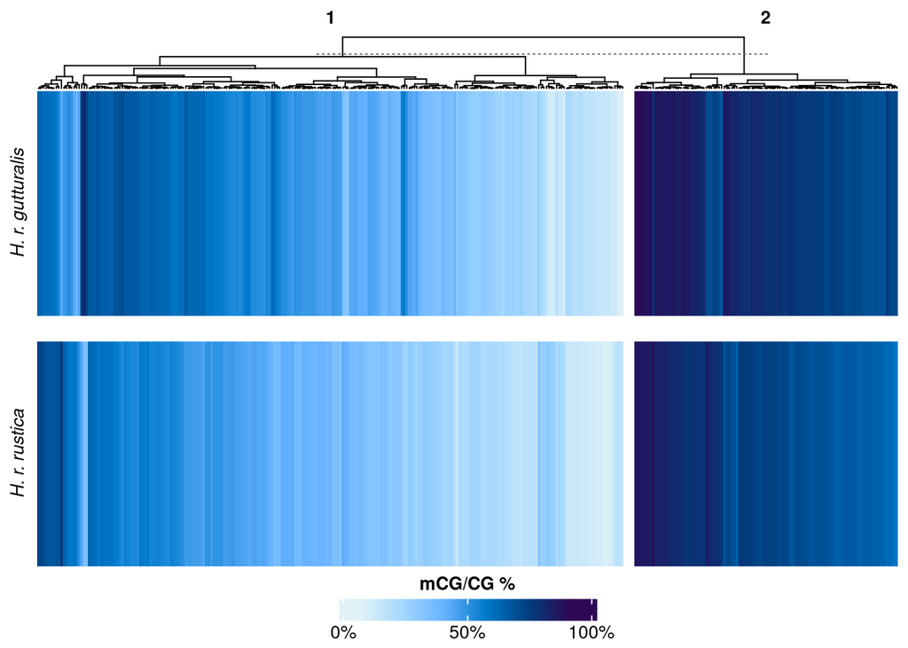

```r
# Now, rows will be 'Rr', 'G' and columns will be the methylation regions
numeric_matrix_transposed <- t(numeric_matrix_original)

# --- Adjusting Ordering and Splitting for the Transposed Heatmap ---

# Clustering will now be on columns (methylation regions)
# row_hclust will become col_hclust, and row_order will become col_order
set.seed(123) # For reproducibility
col_hclust <- hclust(dist(t(numeric_matrix_transposed))) # Cluster the original rows (now columns)
col_order <- col_hclust$order

# The 'rows' of the transposed matrix are now G and Rr. No need to reorder them based on clustering.
# The 'columns' of the transposed matrix (original rows) will be ordered by col_order.
# So, reorder numeric_matrix_transposed by columns:
numeric_matrix_final <- numeric_matrix_transposed[, col_order]

# The 'column_split' now refers to the original methylation regions.
# This logic needs to move from 'row_split' to 'column_split'.
# We need to apply cutree to the original row_hclust, and then map it to the transposed columns.
num_splits <- 2 # Adjust as needed for the desired number of blocks
# Get cluster assignments for the original methylation regions based on col_hclust
cluster_assignments_ordered <- cutree(col_hclust, k = num_splits)[col_order]
final_column_split <- as.character(cluster_assignments_ordered)


# The 'row_split' will now refer to the original column names (Rr, G).
# Still want a gap between Rr and G (which are now rows).
# Define the new row split for the two rows (Rr, G)
row_split_labels <- c("H. r. rustica", "H. r. gutturalis")
names(row_split_labels) <- rownames(numeric_matrix_final) # Map to the actual row names: "Rr", "G"

# Define heatmap colors
heatmap_colors <- colorRampPalette(c("#E0F2F7", "#A5D8FF", "#66B2FF", "#007ACC", "#004080", "#2E0854"))(100)

# --- Create Heatmap (Arguments swapped for transposed matrix) ---
rg1 <- Heatmap(numeric_matrix_final, # Use the transposed matrix
               cluster_rows = FALSE, # We don't want to cluster the populations (Rr, G)
               cluster_columns = TRUE, # We now cluster the methylation regions (original rows)
               show_row_dend = FALSE, # No dendrogram for populations
               show_column_dend = TRUE, # Show dendrogram for methylation regions (now columns)
               col = heatmap_colors,
               name = "mCG/CG %",
               # column_labels are now the methylation region IDs, which you hide.
               # row_labels are now "Rr" and "G", which you probably want to see.
               row_split = row_split_labels, # Split populations (now rows)
               column_split = final_column_split, # Split methylation regions (now columns)
               show_row_names = FALSE, # Show "Rr" and "G" labels
               show_column_names = FALSE, # Hide methylation region IDs
               row_names_rot = 0, # Keep "Rr" and "G" horizontal
               column_names_rot = 90, # Rotate methylation region IDs if shown (but they are hidden)
               row_title_gp = gpar(fontsize = 10, fontface = "italic"), # New: column titles become row titles
               column_title_rot = 0, # New: row titles become column titles
               column_title_gp = gpar(fontsize = 10, fontface = "bold"),
               row_gap = unit(5, "mm"), # Gap between populations (now rows)
               column_gap = unit(2, "mm"), # Gap between methylation region splits (now columns)
               heatmap_legend_param = list(
                 title = "mCG/CG %",
                 at = c(0, 0.5, 1),
                 labels = c("0%", "50%", "100%"),
                 direction = "horizontal",
                 title_position = "topcenter",
                 labels_rot = 0,
                 legend_width = unit(5, "cm")
               )
)

# Draw the heatmap
draw(rg1, heatmap_legend_side = "bottom")
```

## Plot island, flank and opensea

Visually I want to separate islands/flanks/opensea so that it is clear the relative number of PST outliers from each category.

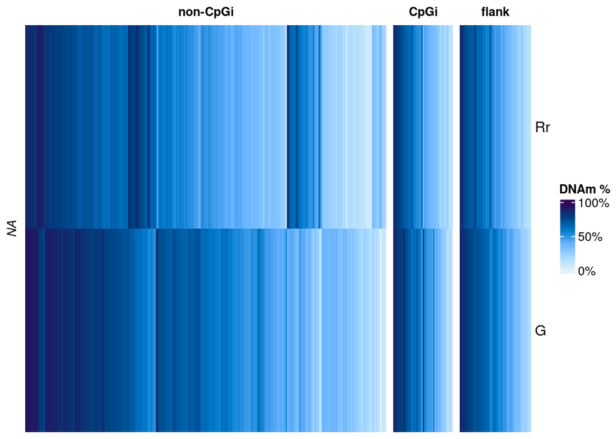

```r
# --- Data Preparation ---
pst_rg <- top_1_pst_rgt_cat %>%
  filter(pop1 == "gutturalis", pop2 == "rustica.r")

prop.df <- prop.RGT %>%
  dplyr::select(contains("RU_13_R_") | contains("_G_") | contains("region.id"))

population_groups <- list(Rr = "RU_13_R_", G = "_G_")

population_means <- sapply(names(population_groups), function(pop) {
  cols <- grep(population_groups[[pop]], colnames(prop.df), value = TRUE)
  if (length(cols) == 0) return(NULL)
  apply(prop.df[, cols, drop = FALSE], 1, function(x) mean(x, na.rm = TRUE))
})

prop.rg <- cbind(prop.df, population_means) %>%
  dplyr::select(region.id, Rr, G)

# Initial data preparation
pst_prop <- pst_rg %>%
  left_join(prop.rg, by = c("site.id" = "region.id")) # Ensure 'region' column is in pst_prop after this join

# Filter numeric_matrix to only include population averages (G and Rr)
numeric_matrix_original <- pst_prop %>%
  dplyr::select(G, Rr) %>% # Original order
  as.matrix()

# Reorder columns for horizontal flip if desired (Rr then G)
numeric_matrix_original <- numeric_matrix_original[, c("Rr", "G")]

# Set row names for the original matrix (these are your loci/methylation regions)
# CRITICAL: Ensure these row names correspond to the 'site.id' from pst_prop
rownames(numeric_matrix_original) <- pst_prop$site.id

# Now, rows will be 'Rr', 'G' and columns will be the methylation regions
numeric_matrix_transposed <- t(numeric_matrix_original)

# --- Adjusting Ordering and Splitting for the Transposed Heatmap ---

# Define the column split based on 'region' column from pst_prop
# Ensure the order of regions is as desired (Islands, Shores, Shelves, OpenSea)
# First, create a mapping from site.id (which are now column names of transposed matrix) to their region.
# This requires pst_prop to have the 'site.id' and 'region' columns, and they should align.
site_region_map <- pst_prop %>%
  dplyr::select(site.id, region) %>%
  # Filter to only include sites present in your matrix columns
  filter(site.id %in% colnames(numeric_matrix_transposed)) %>%
  # Ensure the order of this map matches the columns of your matrix
  # This is important for 'column_split' to work correctly.
  arrange(match(site.id, colnames(numeric_matrix_transposed)))

###Convert to the correct naming for the figure
site_region_map$region[site_region_map$region == "opensea"] <- "non-CpGi"
site_region_map$region[site_region_map$region == "island"] <- "CpGi"
site_region_map$region[site_region_map$region == "shore"] <- "flank"

desired_region_order <- c("CpGi", "flank", "non-CpGi") # Adjust these names to match your data exactly

# 2. Clustering will still be on columns (methylation regions) within each split
# No need for manual col_hclust and col_order if you let Heatmap handle it within splits.
# The 'cluster_columns = TRUE' in Heatmap will automatically cluster within each 'column_split' group.

# The 'rows' of the transposed matrix are now G and Rr. No need to reorder them based on clustering.
# Define the new row split for the two rows (Rr, G)
row_split_labels <- c("H. r. rustica" = "Rr", "H. r. gutturalis" = "G") # Correctly name the vector by row names
# This assumes your row names are exactly "Rr" and "G"

# Define heatmap colors
heatmap_colors <- colorRampPalette(c("#E0F2F7", "#A5D8FF", "#66B2FF", "#007ACC", "#004080", "#2E0854"))(100)

# --- Create Heatmap (Arguments swapped for transposed matrix) ---
rg1 <- Heatmap(numeric_matrix_transposed, # Use the transposed matrix
               cluster_rows = FALSE, # We don't want to cluster the populations (Rr, G)
               cluster_columns = TRUE, # We now cluster the methylation regions (original rows) within splits
               show_row_dend = FALSE, # No dendrogram for populations
               show_column_dend = FALSE, # Show dendrogram for methylation regions (now columns)
               col = heatmap_colors,
               name = "mCG/CG %",
               row_split = factor(rownames(numeric_matrix_final), levels = names(row_split_labels)), # Ensure row split is a factor with desired order
               column_split = factor(site_region_map$region, levels = desired_region_order), # Split methylation regions by their genomic region type
               show_row_names = TRUE, # Show "Rr" and "G" labels (changed from FALSE to TRUE)
               show_column_names = FALSE, # Hide methylation region IDs
               row_names_rot = 0, # Keep "Rr" and "G" horizontal
               column_names_rot = 90, # Rotate methylation region IDs if shown (but they are hidden)
               row_title_gp = gpar(fontsize = 10, fontface = "italic"), # New: column titles become row titles
               column_title_rot = 0, # New: row titles become column titles
               column_title_gp = gpar(fontsize = 10, fontface = "bold"),
               row_gap = unit(5, "mm"), # Gap between populations (now rows)
               column_gap = unit(2, "mm"), # Gap between methylation region splits (now columns)
               heatmap_legend_param = list(
                 title = "DNAm %",
                 at = c(0, 0.5, 1),
                 labels = c("0%", "50%", "100%"),
                 direction = "vertical",
                 title_position = "topcenter",
                 labels_rot = 0,
                 legend_width = unit(5, "cm")
               )
)

# Draw the heatmap
rg1 <- draw(rg1, heatmap_legend_side = "right")
```

```r
summary(as.factor(site_region_map$region))
```

```
##     CpGi    flank non-CpGi
##      152      183      923
```

Save image

```r
# Open PNG graphics device
png("/dss/dsslegfs01/pr53da/pr53da-dss-0034/projects/2021_SwallowRRBS/4_RGT_Hybrids/2_Parental_high_PST/1_Figure3_RG_Heatmap.png", width = 6, height = 2, units = "in", res = 500)
# Draw the heatmap and control the legend position and split order
draw(rg1, heatmap_legend_side = "right", cluster_column_slices = FALSE)
# Close the graphics device to save the file
dev.off()
```